# Boosted Tree Algorithm: An Illustration

Machine Learning in Economics

Prof. Dr. Hüseyin Taştan

Yildiz Technical University

## 🔍 The Boosted Tree Algorithm

Boosting is an ensemble method that constructs a strong predictor by sequentially adding **weak learners**, typically shallow decision trees. The general process is:

- Initialize the model with a constant prediction:

  $$\hat{f}_0(x) = \text{initial estimate (e.g., mean of } y)$$
- For $b = 1, 2, \dots, B$:
  1. Compute the residuals (or pseudo-residuals):

     $$r_i^{(b)} = y_i - \hat{f}_{b-1}(x_i)$$
  2. Fit a shallow tree $\hat{g}_b(x)$, often of small depth, to these residuals.
  3. Update the model:

     $$\hat{f}_b(x) = \hat{f}_{b-1}(x) + \lambda \hat{g}_b(x)$$
- The **learning rate** $\lambda$ controls how aggressively the model adapts (smaller $\lambda$ means slower learning).
- The **final prediction** after $B$ iterations is the sum:

  $$\boxed{
  \hat{f}(x) = \hat{f}_0(x) + \sum_{b=1}^{B} \lambda \hat{g}_b(x)
  }$$

This approach reduces bias by iteratively correcting errors, while controlling complexity with the learning rate and shallow trees.

## 📊 Illustration using Simulated Data

We generate synthetic data from a nonlinear function with noise:

```r
set.seed(42)

n <- 200
x <- runif(n, -2, 2)
f_true <- function(x) 2 * x + sin(3 * x)
y <- f_true(x) + rnorm(n, 0, 1)
data <- data.frame(x = x, y = y)

# Grid for smoother prediction line
x_grid <- seq(-2, 2, length.out = 500)
grid_df <- data.frame(x = x_grid)
```

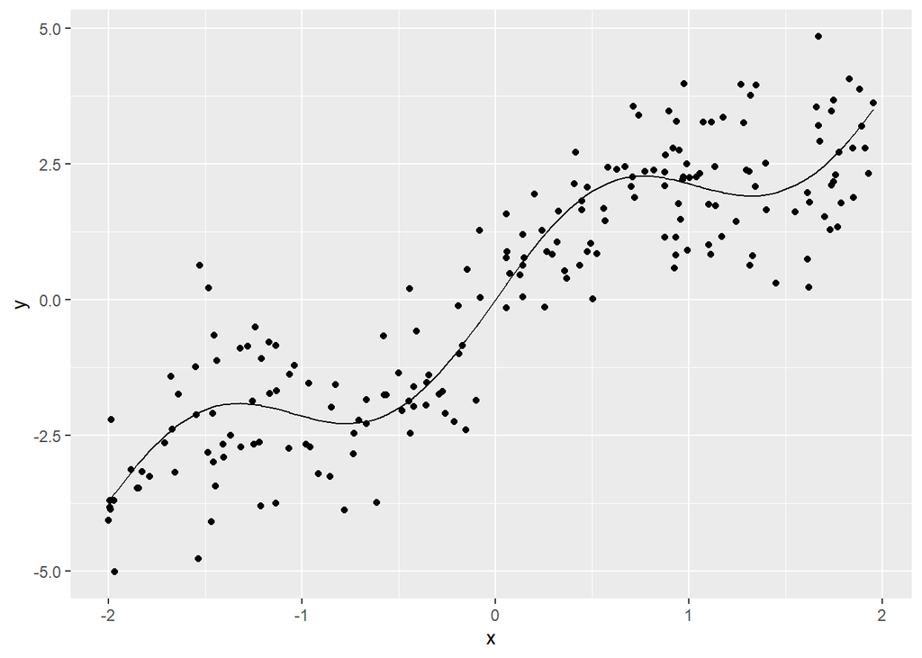

```r
data |>
  mutate(ftrue = f_true(x)) |>
  ggplot(aes(x,y)) +
  geom_point() +
  geom_line(aes(x, ftrue))
```

## 🚀 Boosting Loop with Shallow Trees

We illustrate the boosting process step by step with:

- **B = 5** boosting rounds
- **d = 1** (decision stumps - depth of tree)
- **λ = 0.1** learning rate

We show: - The prediction function at selected rounds - The residual tree at that round

```r
B <- 5         # number of boosting rounds
lambda <- 0.1  # learning rate (shrinkage)
depth <- 1     # d = tree depth

F_pred <- rep(0, n) # zero vector, initial predictions
pred_grid <- rep(0, length(x_grid))

preds_list <- list()
trees_list <- list()

for (b in 1:B) {
  residuals <- y - F_pred      # obtain residuals
  fit <- rpart(residuals ~ x,  # fit an unpruned tree to the residuals
               data = data,
               control = rpart.control(maxdepth = depth, # d
                                       cp = 0            # no pruning
                                       )
               )
  update <- predict(fit, newdata = data) # update predictions
  update_grid <- predict(fit, newdata = grid_df) #

  F_pred <- F_pred + lambda * update  # predictions at iteration b
  pred_grid <- pred_grid + lambda * update_grid

  # save predictions and trees
  preds_list[[b]] <- data.frame(x = x_grid,
                                pred = pred_grid,
                                round = paste("Round", b))
  trees_list[[b]] <- fit
}
```

## 🖼️ Visualizing the Boosting Process

Below, we plot the predicted function after each round and show the residual tree used at that round.

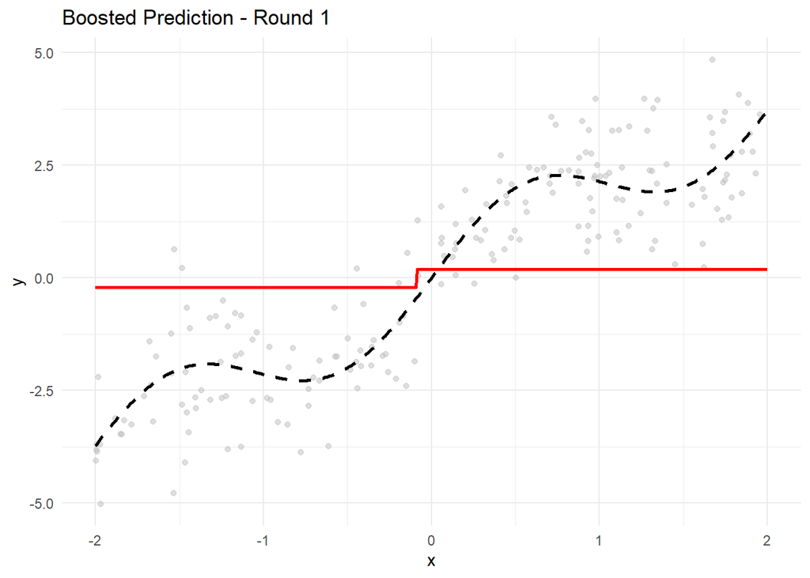

```r
# round 1, b=1
pred_df <- preds_list[[1]]

  # Function prediction plot
ggplot() +
    geom_point(data = data,
               aes(x = x, y = y),
               alpha = 0.5, color = "gray") +
    geom_line(aes(x = x_grid, y = f_true(x_grid)),
              color = "black", linetype = "dashed", size = 1) +
    geom_line(data = pred_df, aes(x = x, y = pred),
              color = "red", size = 1) +
    ggtitle(paste("Boosted Prediction -", pred_df$round[1])) +
    theme_minimal()
```

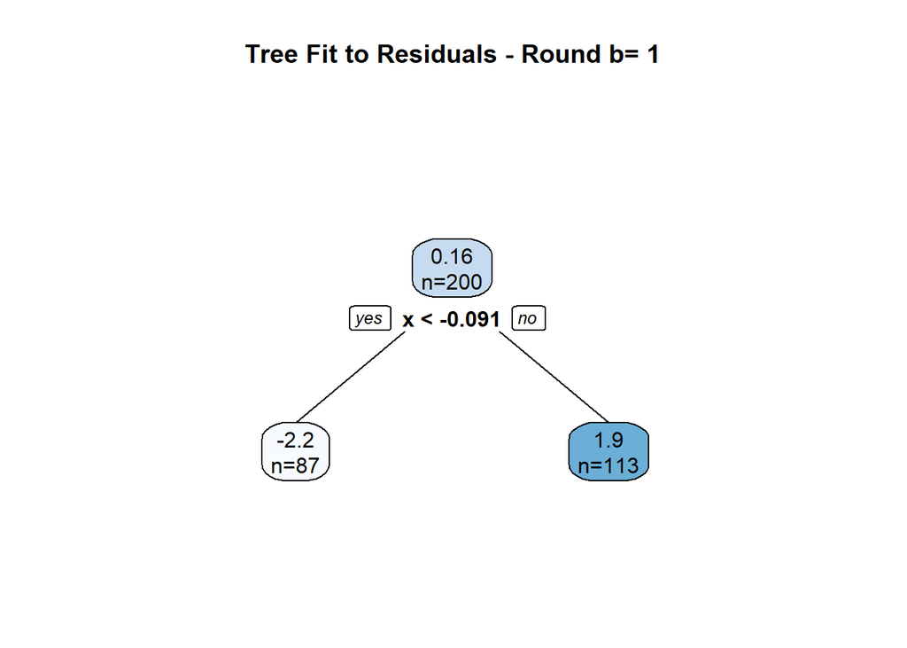

```r
library(rpart.plot)
b=1
prp(trees_list[[b]],
    main = paste("Tree Fit to Residuals - Round b=", b),
    type = 2, extra = 1, box.palette = "Blues")
```

Note that the tree above is the fitted shallow tree (a stump since d=1). The predictions from this tree is scaled by the learning rate (lambda) as shown in the previous plot.

Let’s see the second round:

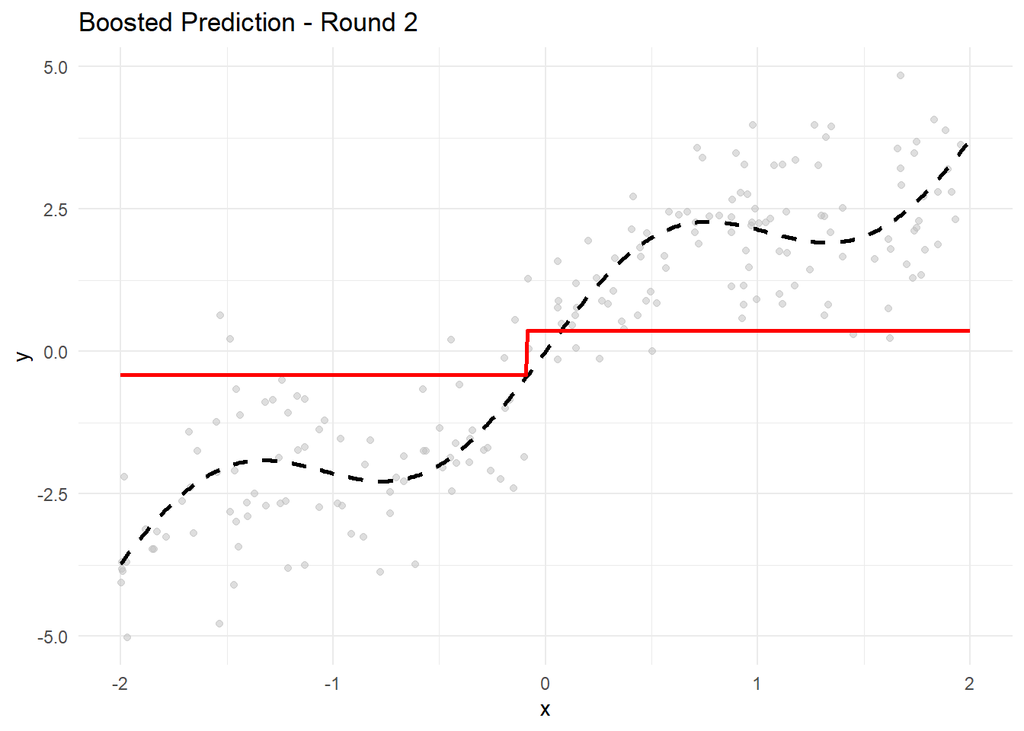

```r
# round 2, b=2
pred_df <- preds_list[[2]]

  # Function prediction plot
ggplot() +
    geom_point(data = data,
               aes(x = x, y = y),
               alpha = 0.5, color = "gray") +
    geom_line(aes(x = x_grid, y = f_true(x_grid)),
              color = "black", linetype = "dashed", size = 1) +
    geom_line(data = pred_df, aes(x = x, y = pred),
              color = "red", size = 1) +
    ggtitle(paste("Boosted Prediction -", pred_df$round[2])) +
    theme_minimal()
```

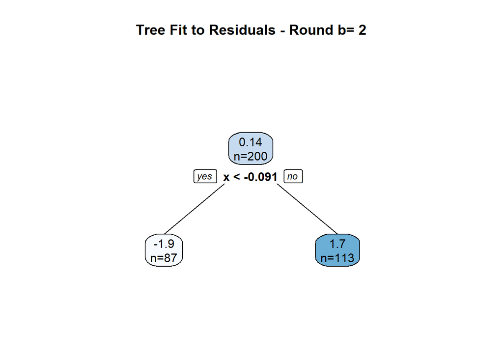

```r
b=2
prp(trees_list[[b]],
    main = paste("Tree Fit to Residuals - Round b=", b),
    type = 2, extra = 1, box.palette = "Blues")
```

Let’s see the third round:

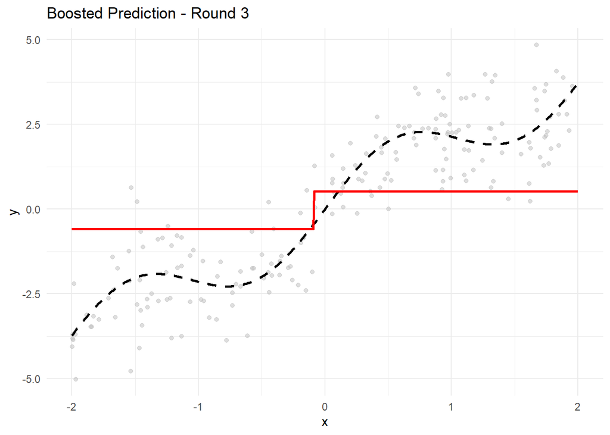

```r
# round 3, b=3
pred_df <- preds_list[[3]]

  # Function prediction plot
ggplot() +
    geom_point(data = data,
               aes(x = x, y = y),
               alpha = 0.5, color = "gray") +
    geom_line(aes(x = x_grid, y = f_true(x_grid)),
              color = "black", linetype = "dashed", size = 1) +
    geom_line(data = pred_df, aes(x = x, y = pred),
              color = "red", size = 1) +
    ggtitle(paste("Boosted Prediction -", pred_df$round[3])) +
    theme_minimal()
```

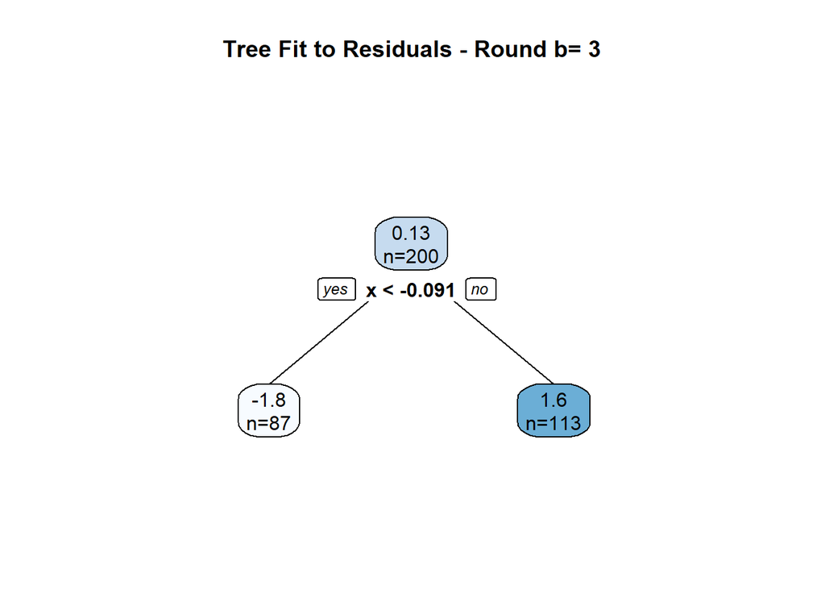

```r
b=3
prp(trees_list[[b]],
    main = paste("Tree Fit to Residuals - Round b=", b),
    type = 2, extra = 1, box.palette = "Blues")
```

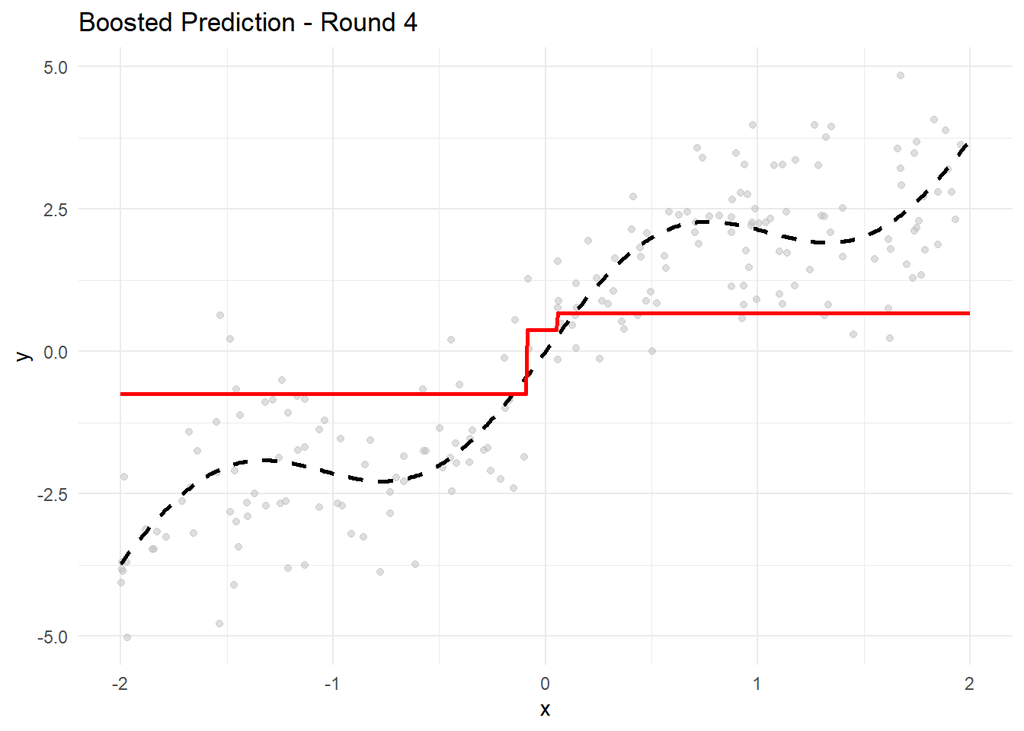

```r
# round 4, b=4
pred_df <- preds_list[[4]]

  # Function prediction plot
ggplot() +
    geom_point(data = data,
               aes(x = x, y = y),
               alpha = 0.5, color = "gray") +
    geom_line(aes(x = x_grid, y = f_true(x_grid)),
              color = "black", linetype = "dashed", size = 1) +
    geom_line(data = pred_df, aes(x = x, y = pred),
              color = "red", size = 1) +
    ggtitle(paste("Boosted Prediction -", pred_df$round[4])) +
    theme_minimal()
```

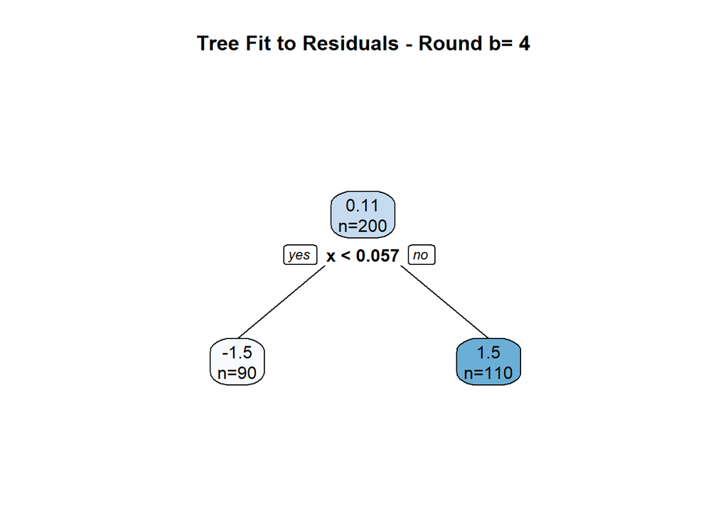

```r
b=4
prp(trees_list[[b]],
    main = paste("Tree Fit to Residuals - Round b=", b),
    type = 2, extra = 1, box.palette = "Blues")
```

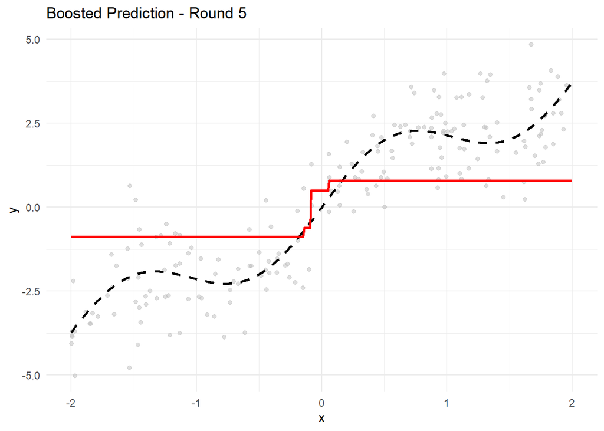

```r
# round 5, b=5
pred_df <- preds_list[[5]]

  # Function prediction plot
ggplot() +
    geom_point(data = data,
               aes(x = x, y = y),
               alpha = 0.5, color = "gray") +
    geom_line(aes(x = x_grid, y = f_true(x_grid)),
              color = "black", linetype = "dashed", size = 1) +
    geom_line(data = pred_df, aes(x = x, y = pred),
              color = "red", size = 1) +
    ggtitle(paste("Boosted Prediction -", pred_df$round[5])) +
    theme_minimal()
```

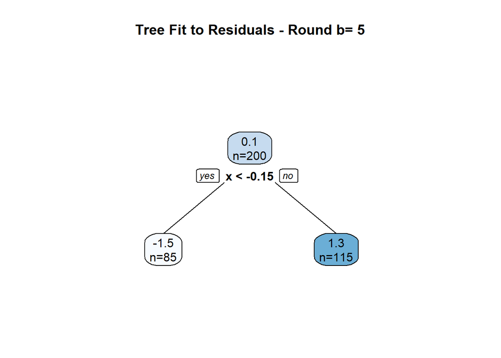

```r
b=5
prp(trees_list[[b]],
    main = paste("Tree Fit to Residuals - Round b=", b),
    type = 2, extra = 1, box.palette = "Blues")
```

Visualize the progression:

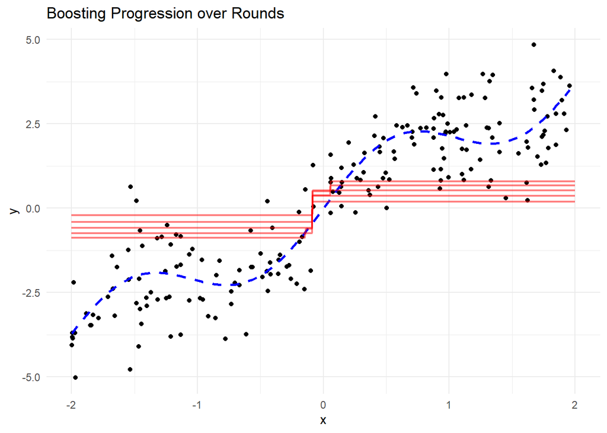

```r
# Visualize the data, true function, and predictions at different rounds
library(ggplot2)

ggplot(data, aes(x, y)) +
  geom_point() +
  geom_line(aes(x, f_true(x)), color = "blue", size = 1, linetype = "dashed") +
  # Add predictions from different boosting rounds
  lapply(seq_along(preds_list), function(i) {
    geom_line(data = preds_list[[i]], aes(x, pred),
              color = "red", alpha = 0.5, size = 0.8,
              linetype = "solid", show.legend = FALSE)
  }) +
  theme_minimal() +
  labs(title = "Boosting Progression over Rounds")
```

We should increase B to improve the predictions. Rerun the boosting algorithm:

```r
B <- 100         # number of boosting rounds
lambda <- 0.1  # learning rate (shrinkage)
depth <- 1     # d = tree depth

F_pred <- rep(0, n) # zero vector, initial predictions
pred_grid <- rep(0, length(x_grid))

preds_list <- list()
trees_list <- list()

for (b in 1:B) {
  residuals <- y - F_pred      # obtain residuals
  fit <- rpart(residuals ~ x,  # fit an unpruned tree to the residuals
               data = data,
               control = rpart.control(maxdepth = depth, # d
                                       cp = 0            # no pruning
                                       )
               )
  update <- predict(fit, newdata = data) # update predictions
  update_grid <- predict(fit, newdata = grid_df) #

  F_pred <- F_pred + lambda * update  # predictions at iteration b
  pred_grid <- pred_grid + lambda * update_grid

  # save predictions and trees
  preds_list[[b]] <- data.frame(x = x_grid,
                                pred = pred_grid,
                                round = paste("Round", b))
  trees_list[[b]] <- fit
}
```

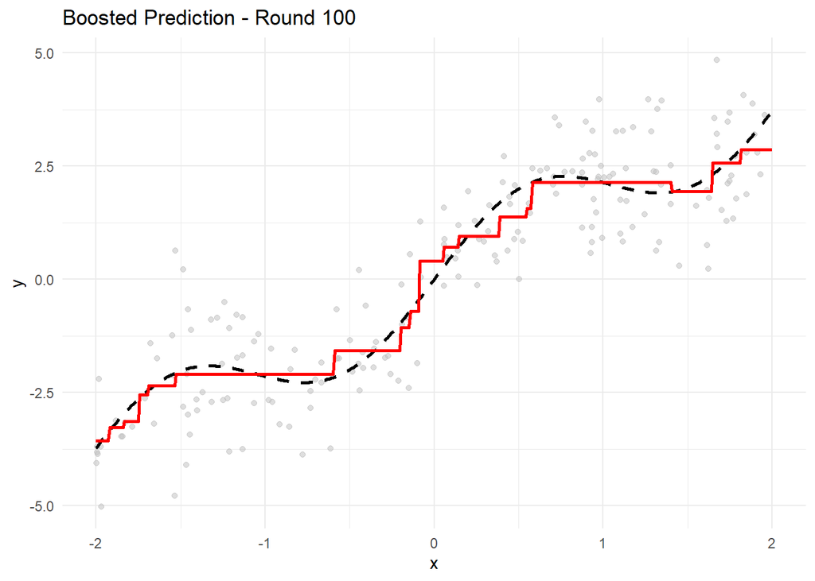

```r
# round 100
b=100
pred_df <- preds_list[[b]]

  # Function prediction plot
ggplot() +
    geom_point(data = data,
               aes(x = x, y = y),
               alpha = 0.5, color = "gray") +
    geom_line(aes(x = x_grid, y = f_true(x_grid)),
              color = "black", linetype = "dashed", size = 1) +
    geom_line(data = pred_df, aes(x = x, y = pred),
              color = "red", size = 1) +
    ggtitle(paste("Boosted Prediction -", pred_df$round[b])) +
    theme_minimal()
```

After 100 iterations we see that the predictions follow the true function more closely.

The individual tree at the last iteration can also be visualized:

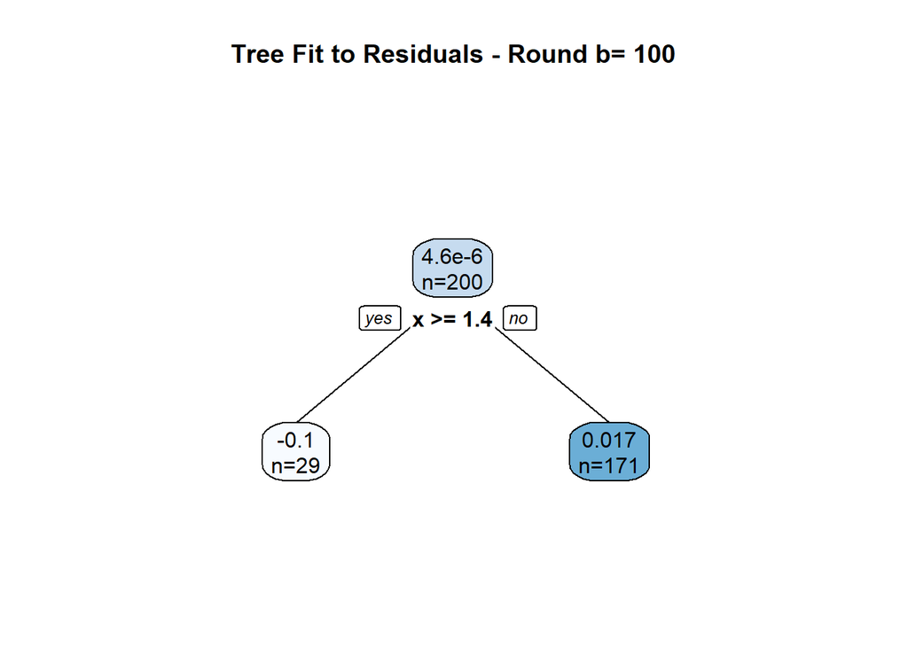

```r
b=100
prp(trees_list[[b]],
    main = paste("Tree Fit to Residuals - Round b=", b),
    type = 2, extra = 1, box.palette = "Blues")
```

## 🧮 Final Aggregation

After $B = 500$ rounds, the final boosted predictor is:

```r
B <- 500         # number of boosting rounds
lambda <- 0.1  # learning rate (shrinkage)
depth <- 1     # d = tree depth

F_pred <- rep(0, n) # zero vector, initial predictions
pred_grid <- rep(0, length(x_grid))

preds_list <- list()
trees_list <- list()

for (b in 1:B) {
  residuals <- y - F_pred      # obtain residuals
  fit <- rpart(residuals ~ x,  # fit an unpruned tree to the residuals
               data = data,
               control = rpart.control(maxdepth = depth, # d
                                       cp = 0            # no pruning
                                       )
               )
  update <- predict(fit, newdata = data) # update predictions
  update_grid <- predict(fit, newdata = grid_df) #

  F_pred <- F_pred + lambda * update  # predictions at iteration b
  pred_grid <- pred_grid + lambda * update_grid

  # save predictions and trees
  preds_list[[b]] <- data.frame(x = x_grid,
                                pred = pred_grid,
                                round = paste("Round", b))
  trees_list[[b]] <- fit
}
```

We can compare the final boosted prediction with the true function:

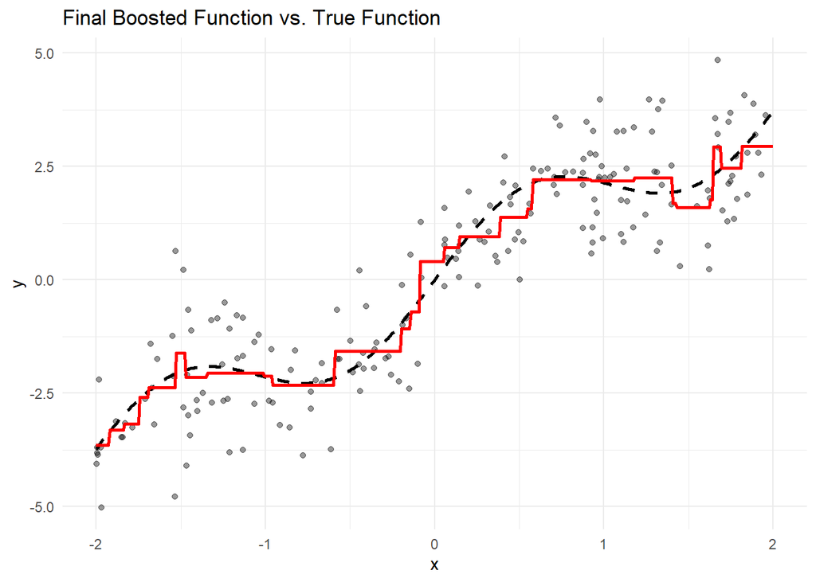

```r
final_pred <- preds_list[[B]]
ggplot() +
  geom_point(data = data, aes(x = x, y = y), alpha = 0.4) +
  geom_line(aes(x = x_grid, y = f_true(x_grid)), color = "black", linetype = "dashed", size = 1) +
  geom_line(data = final_pred, aes(x = x, y = pred), color = "red", size = 1) +
  ggtitle("Final Boosted Function vs. True Function") +
  theme_minimal()
```

Note that using a large $B$ can result in overfitting. It should be chosen using cross-validation.